# Audição Cognitiva - Atividade Final - Audio Real

Jônatas Bertolazzo RM 334035, Letticia Nicoli RM 333658, Renato Ramos RM 333135

28/11/2019

# Análise de texto e áudio em um ambiente real

### Áudio REAL

Neste trabalho vamos analisar e comparar os audios e suas transcrições, visando a maior proximidade possível com um ambiente real de utilização das técnicas de audição cognitiva.

## - Propriedade do Áudio

Vamos começar a nossa análise pelas propriedades do audio que estamos utilizando em questão.

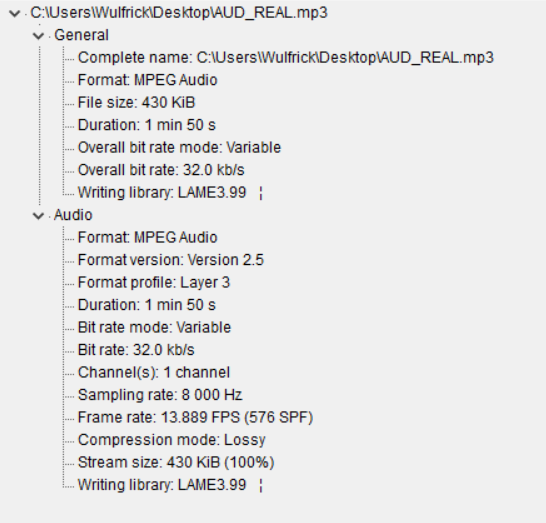

Utiizando o programa **MediaInfo** conseguimos obter diversas informações sobre o áudio que vamos utilizar para análise, entre elas temos como mais importantes:

- Formato : **MPEG**
- Taxa de Bits: **32 kb/s**
- Número de canais: **Mono (1 canal)**
- Taxa de Amostragem: **8 kHz**

Após isso utilizamos a ferramenta demo do Watson para ouvir e transcrever este áudio.

## - Cálculo de Erro

Com a transcrição em mãos, vamos calcular a taxa de erro dada pelo retorno da trasncrição provida pelo próprio Watson, assim chegamos nos valores de:

- S (Substituição): **57**
- D (Exclusão): **7**
- I (Inserção): **5**
- W (Total de Palavras): **169**

## - Análise do Texto Transcrito

```r
cps <- tm_map(cps, stripWhitespace)
cps <- tm_map(cps, content_transformer(tolower))
cps <- tm_map(cps, removeNumbers)
```

Depois de fazer este primeiro tratamento podemos ver o estado em que o nosso texto e suas principais palavras se encontram, para isso utilizamos uma plotagem no estilo “Wordcloud”.

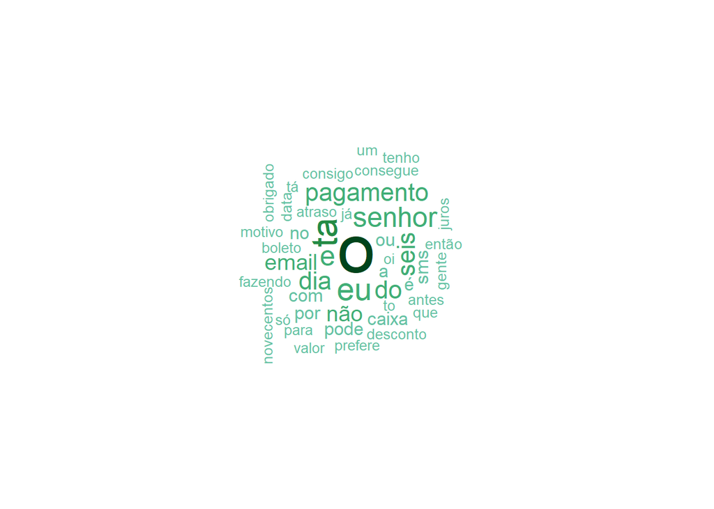

```r
tdm <- TermDocumentMatrix(cps,
                          control = list(wordLengths = c(1, Inf)))

m <- as.matrix(tdm)
word.freq <- sort(rowSums(m), decreasing = T)
pal <- brewer.pal(9, "BuGn")
pal <- pal[-(1:4)]

library(wordcloud)
wordcloud(words = names(word.freq), freq = word.freq, min.freq = 2,
          random.order = F, colors = pal)
```

passamos então para a análise e retirada de Stopwords, começando com a biblioteca padrão de stopwords de palavras em português.

```r
cps <- tm_map(cps, removeWords, stopwords("portuguese"))
```

Utilizamos do processo de TDM para a criação de uma matrix termos para que seja possível separar quais são os termos mais frequentes.

```r
tdm <- TermDocumentMatrix(cps,
                          control = list(wordLengths = c(1, Inf)))
```

Com as palavras separadas, olhamos as palavras mais frequentes da nossa lista.

Neste caso estamos visulizando as palavras com uma frequencia maior do que 2 (Por se tratar de apenas uma transcrição e um texto pequeno).

```r
(freq.terms <- findFreqTerms(tdm, lowfreq = 2))
```

```
##  [1] "antes"      "atraso"     "boleto"     "caixa"      "consegue"
##  [6] "consigo"    "data"       "desconto"   "dia"        "email"
## [11] "então"      "fazendo"    "gente"      "juros"      "motivo"
## [16] "novecentos" "obrigado"   "oi"         "pagamento"  "pode"
## [21] "prefere"    "seis"       "senhor"     "sms"        "ta"
## [26] "to"         "tá"         "valor"      "é"
```

Aqui reparamos que algumas palavras ainda não são tão importantes exclusivamente para a análise que queremos fazer e podemos retirá-las assim como fizemos com os Stopwords.

```r
cps <- tm_map(cps, removeWords, c("wer", '-', '"', 'wav', 'flac', 'mp3', 'tão', 'é', 'né', "dois", "t", "o", "ta", "to", "tá"))

tdm <- TermDocumentMatrix(cps,
                          control = list(wordLengths = c(1, Inf)))
```

Podemos repetir este processo, como já fizemos, várias vezes, a fim de ir moldando a nossa base para que seja possível retirar as respostas que queremos dela.

Agora que temos a base tratada da forma que queremos, vamos começar a nossa análise de texto para descobrir sobre o conteúdo relevante que todos esses textos contém.

Novamente vamos utilizar o plot “Wordcloud” para visualizar a disposição das palavras dentro da nossa base e, possívelmente, retirar novos ‘insights’ que podem ajudar na nossa análise.

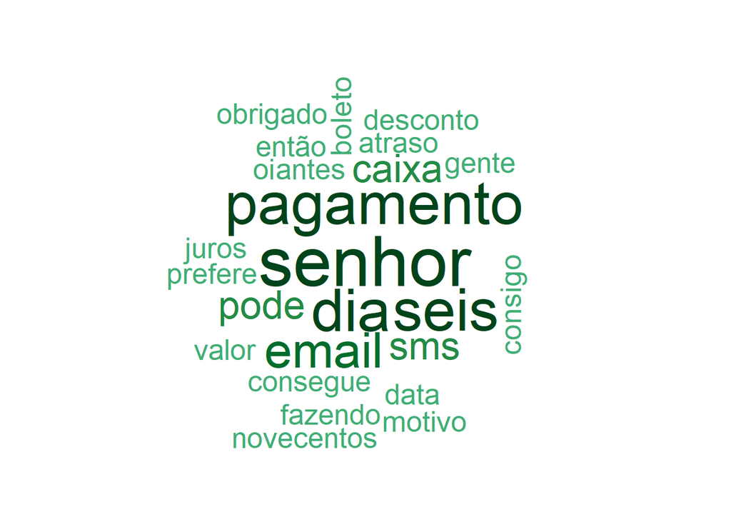

```r
m <- as.matrix(tdm)
word.freq <- sort(rowSums(m), decreasing = T)
pal <- brewer.pal(9, "BuGn")
pal <- pal[-(1:4)]

library(wordcloud)
wordcloud(words = names(word.freq), freq = word.freq, min.freq = 2,
          random.order = F, colors = pal)
```

Neste momento continuar a repetir o processo de retirada e plotagem da base levando em configuração as informações que conseguimos através dos processos anteriores.

## - Conclusão

Com todos estes dados podemos enfim concluir a nossa análise.

Analizando o texto trasncrito podemos concluir que a idéia base é:

### “Atendimento sobre pagamento de conta”

Comparando a análise da transcrição com o texto original podemos ver que **a idéia ainda continua a mesma**.